# STATS 506 HW2

Author

Minxuan Chen

Published

September 20, 2023

Github repo: https://github.com/PKUniiiiice/STATS_506

## Problem 1 Dice Game

### a

```r
# For simplicity, for all functions below, we assume the input `x`
# is always legal, i.e. always an integer.

#' Function to for a dice game -- loop version
#'
#' @param x the number of dice to roll
#' @return total winnings or loses
play_dice_loop <- function(x){
  #initial money
  money <- 0
  for (i in 1:x){
    # out of rolling
    out <- sample.int(6,1)
    money <- money - 2 + (-(out%%2)+1)*out
  }
  return (money)
}

#' Function to for a dice game -- built-in R vectorized version
#'
#' @param x the number of dice to roll
#' @return total winnings or loses
play_dice_vec <- function(x){
  #initial money
  money <- rep(-2, x)
  out <- sample.int(6, size=x, replace=TRUE)
  money <- money + (-(out%%2)+1)*out
  return(sum(money))
}

#' Function to for a dice game -- built-in R vectorized version
#'
#' @param x the number of dice to roll
#' @return total winnings or loses
play_dice_vec <- function(x){
  #initial money
  money <- rep(-2, x)
  out <- sample.int(6, size=x, replace=TRUE)
  money <- money + (-(out%%2)+1)*out
  return(sum(money))
}

#' Function to for a dice game -- table version
#'
#' @param x the number of dice to roll
#' @return total winnings or loses
play_dice_table <- function(x){
  out <- factor(sample.int(6, size=x, replace=TRUE), levels=1:6)
  #make a table from out
  out.tab <- table(out)
  money <- -2*x + sum(as.numeric(out.tab[c(2,4,6)])*c(2,4,6))
  return(money)
}

#' Function to for a dice game -- apply version
#'
#' @param x the number of dice to roll
#' @return total winnings or loses
play_dice_apply <- function(x){

  #We def another function to calculate money
  money_cal <- function(x){
    return ( -2 + (-(x%%2)+1) * x )
  }
  out <- sample.int(6, size=x, replace=TRUE)
  money <- sum(sapply(out, money_cal))
  return (money)
}
```

### b

```r
for (x in c(3,3000,100000)){
  cat("Number of dice to roll: ", x, "\n")
  print(play_dice_loop(x))
  print(play_dice_vec(x))
  print(play_dice_table(x))
  print(play_dice_apply(x))
}
```

```
Number of dice to roll:  3
[1] 10
[1] -2
[1] 6
[1] 6
Number of dice to roll:  3000
[1] 62
[1] -204
[1] 58
[1] -24
Number of dice to roll:  1e+05
[1] 262
[1] -20
[1] -896
[1] 1416
```

### c

We use `set.seed()`before each call to control the randomization.

```r
for (i in list(c(3,2873), c(3000,18218))){
  cat("Number of dice to roll: ", i[1], "\n")
  set.seed(i[2])
  print(play_dice_loop(i[1]))

  set.seed(i[2])
  print(play_dice_vec(i[1]))

  set.seed(i[2])
  print(play_dice_table(i[1]))

  set.seed(i[2])
  print(play_dice_apply(i[1]))
}
```

```
Number of dice to roll:  3
[1] 6
[1] 6
[1] 6
[1] 6
Number of dice to roll:  3000
[1] 158
[1] 158
[1] 158
[1] 158
```

The four versions can give the same result.

### d

```r
library(microbenchmark)
ress <- list()
for (x in c(10, 100, 1000, 10000)){
  cat(log10(x)," Number of dice to roll: ", x, "\n")
  result <- microbenchmark(
    loop = play_dice_loop(x),
    vectorized = play_dice_vec(x),
    table = play_dice_table(x),
    apply = play_dice_apply(x)
  )
  ress <- append(ress, list(result))
}
```

```
1  Number of dice to roll:  10
2  Number of dice to roll:  100
3  Number of dice to roll:  1000
4  Number of dice to roll:  10000
```

```r
print(ress)
```

```
[[1]]
Unit: microseconds
       expr  min    lq   mean median    uq   max neval
       loop 41.7 44.15 46.935  45.95 48.75  59.8   100
 vectorized  6.4  7.30  9.877   8.80  9.95  80.0   100
      table 71.5 76.50 86.837  79.00 85.50 225.3   100
      apply 28.9 31.15 36.114  34.90 37.30  97.9   100

[[2]]
Unit: microseconds
       expr   min     lq    mean median     uq    max neval
       loop 414.8 430.90 483.620 449.10 457.65 3262.7   100
 vectorized  13.2  15.25  18.002  17.50  19.15   49.3   100
      table  86.2  95.05 108.498 101.05 113.80  184.8   100
      apply 104.4 113.00 120.908 118.20 125.60  164.8   100

[[3]]
Unit: microseconds
       expr    min      lq     mean  median      uq    max neval
       loop 4235.8 4285.80 4731.220 4357.55 4631.95 7657.7   100
 vectorized   79.6   85.50   95.723   89.75   92.35  323.0   100
      table  174.5  202.95  246.174  234.80  285.80  454.2   100
      apply  861.7  888.00 1011.268  920.45  952.75 3479.4   100

[[4]]
Unit: microseconds
       expr     min       lq      mean   median       uq     max neval
       loop 43328.8 46779.60 50969.985 48149.40 53458.15 87930.7   100
 vectorized   734.6   751.10   815.669   763.90   795.05  1567.9   100
      table  1030.3  1118.70  1185.662  1144.85  1237.60  1657.6   100
      apply  8676.1  9096.65 10245.095  9562.80 10708.55 16737.9   100
```

It’s obvious that the vectorized version is the fastest, while the pure for-loop version is the slowest. This is a natural result of the fact that built-in vectorized functions are executed in compiled C or Fortran code, as opposed to much more R codes that a for-loop uses.

As for the `apply` version, it involves loop-hiding. We use `sapply`, which calls `lapply`. The later drop down to C for its loops, however, at each step in the C loop, they evaluate the R function (i.e. `money_cal`) passed in. So it is slower than vectorization but not as slow as a pure for-loop.

Upon closer examination of the time cost as it changes from 10 to 10000, we observe distinct patterns. The for-loop and `apply` versions show a linear increase with a slope approx 1. In contrast, the table and vectorization versions display a relatively flatter curve initially.

### e

We care about the total amount of money after $n$ dice games, denoting it by $X_n$. Let $M_i$ represent the single income we obtain after the i-th dice game . $M_i$s are i.i.d. Then
$$X_n = \sum_{i=1}^nM_i$$
To judge whether the game is fair, we calculate
$$EX_n = E\left(\sum_{i=1}^nM_i\right) = nEM_1$$
In theory
$$EM_1 = \frac{1}{6}(-2\times6+2+4+6)=0 \to EX_n=0$$
That is, no matter how many games we play, the expected income is 0, so this is a fair game.

We can show this conclusion using Monte Carlo simulation. Our goal is to estimate $EM_1$. Due to i.i.d of $M_i$s, we can directly use the output of `play_dice(n)`. For example, if the sample size is 10000000,

```r
play_dice_vec(10000000)/10000000
```

```
[1] -0.0003526
```

This value is close to zero, so we claim that $\widehat{EM_i}=0$, then $\widehat{EX_n}=0$.

## Problem 2 Linear Regression

### a

```r
cars <- read.csv("./cars.csv")

newname <- colnames(cars)
for (i in 1:dim(cars)[2]){
  tmp <- unlist(strsplit(newname[i], "[.]"))
  if (i<4){
    newname[i] = tmp[2]
  }
  else if (i<12){
    newname[i] = paste(tmp[3:length(tmp)],collapse='.')
  }
  else if (i<17){
    newname[i] = paste(tmp[2:length(tmp)],collapse='.')
  }
  else{
    newname[i] = paste(tmp[5:length(tmp)],collapse='.')
  }
}

colnames(cars) <- newname
```

### b

```r
cars <- cars[cars$Fuel.Type=="Gasoline", ]
```

### c

We need to introduce these variables into the model for controlling.

```r
# we need to convert year to factor at first
cars$f.years <- as.factor(cars$Year)

m.mpg <- lm(Highway.mpg ~ Horsepower + Torque + Height +
                          Length + Width + f.years, data=cars,
            x=TRUE)

summary(m.mpg)
```

```
Call:
lm(formula = Highway.mpg ~ Horsepower + Torque + Height + Length +
    Width + f.years, data = cars, x = TRUE)

Residuals:
    Min      1Q  Median      3Q     Max
-10.824  -2.550  -0.452   2.372 202.639

Coefficients:
              Estimate Std. Error t value Pr(>|t|)
(Intercept) 32.2926630  0.7225982  44.690  < 2e-16 ***
Horsepower   0.0163556  0.0022772   7.182 7.96e-13 ***
Torque      -0.0507425  0.0022030 -23.034  < 2e-16 ***
Height       0.0099079  0.0011267   8.794  < 2e-16 ***
Length       0.0017290  0.0008836   1.957   0.0504 .
Width       -0.0003343  0.0009045  -0.370   0.7117
f.years2010 -0.4539681  0.6768246  -0.671   0.5024
f.years2011  0.1711016  0.6757043   0.253   0.8001
f.years2012  1.3029279  0.6810076   1.913   0.0558 .
---
Signif. codes:  0 '***' 0.001 '**' 0.01 '*' 0.05 '.' 0.1 ' ' 1

Residual standard error: 4.602 on 4582 degrees of freedom
Multiple R-squared:  0.4192,    Adjusted R-squared:  0.4182
F-statistic: 413.3 on 8 and 4582 DF,  p-value: < 2.2e-16
```

As we use a nominal factor to represent the categorical variable `Year`, the regression result includes three additional variables labeled as `f.years20xx`. These variables represent the differences relative to the reference year, which is `Year=2009`.

From the regression results, $\beta_{\text{Horsepower}}\doteq 0.0164$ indicates that on average MPG on the highway increases by 0.0164 with a unit increase in horsepower, when all other variables in this model are held constant (i.e. controlling all other variables).

(Note: the term “controlling all other variables”  
For those other than `Year`, it means that they are held constant when making comparisons. As for `Year`, which has three terms in the model, it implies we only compare cars released in the same year, i.e., 2009 to 2009, 2010 to 2010, and so on.)

### d

```r
m.inter.mpg <- lm(Highway.mpg ~ Horsepower + Torque +
                                Horsepower:Torque + Height +
                                Length + Width + f.years, data=cars, x=TRUE)

summary(m.inter.mpg)
```

```
Call:
lm(formula = Highway.mpg ~ Horsepower + Torque + Horsepower:Torque +
    Height + Length + Width + f.years, data = cars, x = TRUE)

Residuals:
    Min      1Q  Median      3Q     Max
-11.109  -2.313  -0.258   2.062 203.540

Coefficients:
                    Estimate Std. Error t value Pr(>|t|)
(Intercept)        4.219e+01  7.930e-01  53.199  < 2e-16 ***
Horsepower        -1.666e-02  2.539e-03  -6.563 5.84e-11 ***
Torque            -8.606e-02  2.533e-03 -33.972  < 2e-16 ***
Height             6.560e-03  1.070e-03   6.133 9.32e-10 ***
Length             1.777e-03  8.318e-04   2.136   0.0327 *
Width             -1.169e-03  8.521e-04  -1.372   0.1700
f.years2010       -5.628e-01  6.372e-01  -0.883   0.3771
f.years2011        7.254e-02  6.361e-01   0.114   0.9092
f.years2012        1.197e+00  6.411e-01   1.867   0.0619 .
Horsepower:Torque  1.124e-04  4.628e-06  24.276  < 2e-16 ***
---
Signif. codes:  0 '***' 0.001 '**' 0.01 '*' 0.05 '.' 0.1 ' ' 1

Residual standard error: 4.333 on 4581 degrees of freedom
Multiple R-squared:  0.4854,    Adjusted R-squared:  0.4844
F-statistic: 480.1 on 9 and 4581 DF,  p-value: < 2.2e-16
```

Note that the interaction term has a positive regression coefficient, so we expect that the slope of `MPG-Horsepower` to increase with an increase in Torque.

We choose the 25%, 50% and 75% percentiles of Torque as three typical values to create the interaction plot. Additionally, we fix the `Year` variable to the same value in each plot and generate a total of four plots to reflect four levels of `Year`. As for the other variables (all three dimensions), we use the default value provided by the function `interact_plot()`.

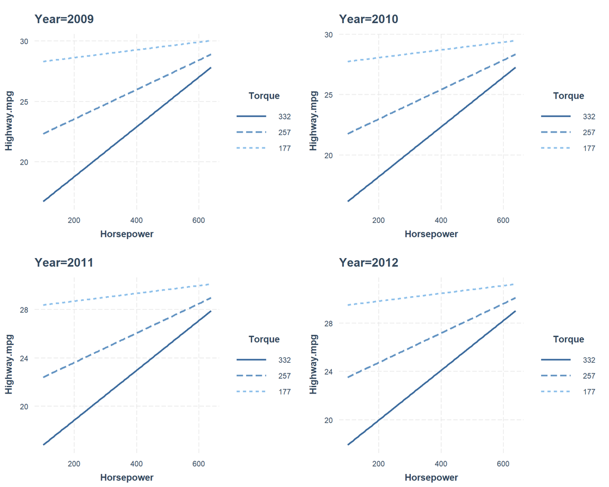

```r
library(interactions)
t1 <- interact_plot(m.inter.mpg, pred=Horsepower, modx=Torque,
                    modx.values=as.numeric(quantile(cars$Torque)[2:4]),
                    at=list(f.years=factor(2009,
                              levels=c("2009", "2010", "2011", "2012")))) +
                    ggplot2::labs(title = "Year=2009")

t2 <- interact_plot(m.inter.mpg, pred=Horsepower, modx=Torque,
                    modx.values=as.numeric(quantile(cars$Torque)[2:4]),
                    at=list(f.years=factor(2010,
                              levels=c("2009", "2010", "2011", "2012")))) +
                    ggplot2::labs(title = "Year=2010")

t3 <- interact_plot(m.inter.mpg, pred=Horsepower, modx=Torque,
                    modx.values=as.numeric(quantile(cars$Torque)[2:4]),
                    at=list(f.years=factor(2011,
                              levels=c("2009", "2010", "2011", "2012")))) +
                    ggplot2::labs(title = "Year=2011")

t4 <- interact_plot(m.inter.mpg, pred=Horsepower, modx=Torque,
                    modx.values=as.numeric(quantile(cars$Torque)[2:4]),
                    at=list(f.years=factor(2012,
                              levels=c("2009", "2010", "2011", "2012")))) +
                    ggplot2::labs(title = "Year=2012")

library(gridExtra)

grid.arrange(t1, t2, t3, t4, ncol = 2)
```

Note that the difference among years lies solely in the intercept (translation of lines). This is because there is no interaction between `Year` and `Horsepower`.

### e

We try to reproduce the results in part c and d.

```r
cal.beta <- function(y, design){
  design <- as.matrix(design)
  xtx.inv <- solve(crossprod(design))
  return (xtx.inv %*% t(design) %*% y)
}

#part c design
design.pc <- cars[c("Horsepower", "Torque", "Height", "Length", "Width")]
design.pc <- cbind(rep(1, dim(cars)[1]),
                   design.pc,
                   model.matrix(~cars$f.years)[,2:4])


#part d design
inter <- cars$Horsepower * cars$Torque
design.pd <- cbind(design.pc, inter)

y.cd <- cars$Highway.mpg

#beta of part c
cal.beta(y.cd, design.pc)
```

```
                              [,1]
rep(1, dim(cars)[1]) 32.2926630057
Horsepower            0.0163556341
Torque               -0.0507424622
Height                0.0099078942
Length                0.0017289759
Width                -0.0003343217
cars$f.years2010     -0.4539681241
cars$f.years2011      0.1711016371
cars$f.years2012      1.3029279007
```

```r
#beta of part d
cal.beta(y.cd, design.pd)
```

```
                              [,1]
rep(1, dim(cars)[1]) 42.1879478687
Horsepower           -0.0166633227
Torque               -0.0860592704
Height                0.0065603903
Length                0.0017767232
Width                -0.0011694485
cars$f.years2010     -0.5627857770
cars$f.years2011      0.0725356431
cars$f.years2012      1.1970329986
inter                 0.0001123567
```

We got the same results as `lm` did prior.

## Problem 3 Stata

All answers are in the following code chunk.

Interaction plot of Part d

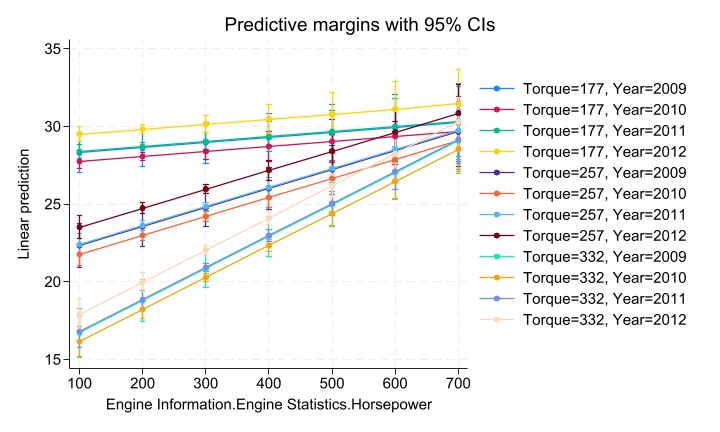

```stata
. do "K:\STATS_506\STATA\stata_hw2.Do"

. //load data
. cd "K:\STATS_506\STATA\"
K:\STATS_506\STATA

. import delimited "cars.csv", clear
(encoding automatically selected: ISO-8859-1)
(18 vars, 5,076 obs)

. describe

Contains data
 Observations:         5,076
    Variables:            18
------------------------------------------------------------------------------------------------------------------------------------------------------------------------------------------
Variable      Storage   Display    Value
    name         type    format    label      Variable label
------------------------------------------------------------------------------------------------------------------------------------------------------------------------------------------
dimensionshei~t int     %8.0g                 Dimensions.Height
dimensionslen~h int     %8.0g                 Dimensions.Length
dimensionswidth int     %8.0g                 Dimensions.Width
engineinform~ne str17   %17s                  Engine Information.Driveline
engineinform~pe str60   %60s                  Engine Information.Engine Type
engineinform~id str4    %9s                   Engine Information.Hybrid
engineinform~rd byte    %8.0g                 Engine Information.Number of Forward Gears
engineinforma~n str30   %30s                  Engine Information.Transmission
fuelinfor~tympg byte    %8.0g                 Fuel Information.City mpg
fuelinformati~e str22   %22s                  Fuel Information.Fuel Type
fuelinfor~aympg int     %8.0g                 Fuel Information.Highway mpg
identificatio~n str22   %22s                  Identification.Classification
identificatio~d str67   %67s                  Identification.ID
identificatio~e str18   %18s                  Identification.Make
identific~lyear str48   %48s                  Identification.Model Year
identific~nyear int     %8.0g                 Identification.Year
engineinforma~c int     %8.0g                 Engine Information.Engine Statistics.Horsepower
v18             int     %8.0g                 Engine Information.Engine Statistics.Torque
------------------------------------------------------------------------------------------------------------------------------------------------------------------------------------------
Sorted by:
     Note: Dataset has changed since last saved.

.
. // Part a ------------------------------------------------------------------------------------------------------------------------
. local oldvars "dimensionsheight dimensionslength dimensionswidth engineinformationdriveline engineinformationenginetype engineinformationhybrid engineinformationnumberofforward enginei
> nformationtransmission fuelinformationcitympg fuelinformationfueltype fuelinformationhighwaympg identificationclassification identificationid identificationmake identificationmodelyear
>  identificationyear engineinformationenginestatistic v18"

.
. local newvars "Height Length Width Driveline EngineType Hybrid NofForwardGears Transmission Citympg FuelType Highwaympg Classification ID Make ModelYear Year Horsepower Torque"

.
. //loop over the table, and change column names
. local items : word count `oldvars'

. forval i = 1/`items' {
  2.     local old : word `i' of `oldvars'
  3.         local new : word `i' of `newvars'
  4.     rename `old' `new'
  5. }

. // End of Part a------------------------------------------------------------------------------------------------------------------
.
.
. // Part b ------------------------------------------------------------------------------------------------------------------------
. keep if FuelType == "Gasoline"
(485 observations deleted)

. // End of Part b------------------------------------------------------------------------------------------------------------------
.
.
. // Part c ------------------------------------------------------------------------------------------------------------------------
. regress Highwaympg Horsepower Torque Height Length Width i.Year

      Source |       SS           df       MS      Number of obs   =     4,591
-------------+----------------------------------   F(8, 4582)      =    413.35
       Model |  70043.6695         8  8755.45869   Prob > F        =    0.0000
    Residual |   97055.298     4,582  21.1818634   R-squared       =    0.4192
-------------+----------------------------------   Adj R-squared   =    0.4182
       Total |  167098.968     4,590  36.4050038   Root MSE        =    4.6024

------------------------------------------------------------------------------
  Highwaympg | Coefficient  Std. err.      t    P>|t|     [95% conf. interval]
-------------+----------------------------------------------------------------
  Horsepower |   .0163556   .0022772     7.18   0.000     .0118913      .02082
      Torque |  -.0507425    .002203   -23.03   0.000    -.0550614   -.0464236
      Height |   .0099079   .0011267     8.79   0.000      .007699    .0121168
      Length |    .001729   .0008836     1.96   0.050    -3.36e-06    .0034613
       Width |  -.0003343   .0009045    -0.37   0.712    -.0021075    .0014388
             |
        Year |
       2010  |  -.4539681   .6768246    -0.67   0.502     -1.78087    .8729342
       2011  |   .1711016   .6757043     0.25   0.800    -1.153604    1.495808
       2012  |   1.302928   .6810076     1.91   0.056    -.0321751    2.638031
             |
       _cons |   32.29266   .7225982    44.69   0.000     30.87602     33.7093
------------------------------------------------------------------------------

. // End of Part c------------------------------------------------------------------------------------------------------------------
.
. // Part d ------------------------------------------------------------------------------------------------------------------------
. regress Highwaympg c.Horsepower##c.Torque Height Length Width i.Year

      Source |       SS           df       MS      Number of obs   =     4,591
-------------+----------------------------------   F(9, 4581)      =    480.07
       Model |  81105.8715         9  9011.76351   Prob > F        =    0.0000
    Residual |   85993.096     4,581  18.7716865   R-squared       =    0.4854
-------------+----------------------------------   Adj R-squared   =    0.4844
       Total |  167098.968     4,590  36.4050038   Root MSE        =    4.3326
```

```stata
---------------------------------------------------------------------------------------
           Highwaympg | Coefficient  Std. err.      t    P>|t|     [95% conf. interval]
----------------------+----------------------------------------------------------------
           Horsepower |  -.0166633   .0025388    -6.56   0.000    -.0216406    -.011686
               Torque |  -.0860593   .0025333   -33.97   0.000    -.0910257   -.0810928
                      |
c.Horsepower#c.Torque |   .0001124   4.63e-06    24.28   0.000     .0001033    .0001214
                      |
               Height |   .0065604   .0010696     6.13   0.000     .0044634    .0086573
               Length |   .0017767   .0008318     2.14   0.033     .0001459    .0034075
                Width |  -.0011694   .0008521    -1.37   0.170      -.00284    .0005011
                      |
                 Year |
                2010  |  -.5627858   .6371716    -0.88   0.377    -1.811949    .6863777
                2011  |   .0725356   .6361142     0.11   0.909    -1.174555    1.319626
                2012  |   1.197033   .6411085     1.87   0.062    -.0598488    2.453915
                      |
                _cons |   42.18795   .7930274    53.20   0.000     40.63323    43.74266
---------------------------------------------------------------------------------------

.
. _pctile Torque, p(25,50,75)

. local q1 = r(r1)

. local q2 = r(r2)

. local q3 = r(r3)

.
. margins, at(Horsepower=(100(100)700) Torque=(`q1' `q2' `q3`'') Year=(2009(1)2012))

Predictive margins                                       Number of obs = 4,591
Model VCE: OLS

Expression: Linear prediction, predict()
1._at:  Horsepower =  100
        Torque     =  177
        Year       = 2009
2._at:  Horsepower =  100
        Torque     =  177
        Year       = 2010
3._at:  Horsepower =  100
        Torque     =  177
        Year       = 2011
4._at:  Horsepower =  100
        Torque     =  177
        Year       = 2012
5._at:  Horsepower =  100
        Torque     =  257
        Year       = 2009
6._at:  Horsepower =  100
        Torque     =  257
        Year       = 2010
7._at:  Horsepower =  100
        Torque     =  257
        Year       = 2011
8._at:  Horsepower =  100
        Torque     =  257
        Year       = 2012
9._at:  Horsepower =  100
        Torque     =  332
        Year       = 2009
10._at: Horsepower =  100
        Torque     =  332
        Year       = 2010
11._at: Horsepower =  100
        Torque     =  332
        Year       = 2011
12._at: Horsepower =  100
        Torque     =  332
        Year       = 2012
13._at: Horsepower =  200
        Torque     =  177
        Year       = 2009
14._at: Horsepower =  200
        Torque     =  177
        Year       = 2010
15._at: Horsepower =  200
        Torque     =  177
        Year       = 2011
16._at: Horsepower =  200
        Torque     =  177
        Year       = 2012
17._at: Horsepower =  200
        Torque     =  257
        Year       = 2009
18._at: Horsepower =  200
        Torque     =  257
        Year       = 2010
19._at: Horsepower =  200
        Torque     =  257
        Year       = 2011
20._at: Horsepower =  200
        Torque     =  257
        Year       = 2012
21._at: Horsepower =  200
        Torque     =  332
        Year       = 2009
22._at: Horsepower =  200
        Torque     =  332
        Year       = 2010
23._at: Horsepower =  200
        Torque     =  332
        Year       = 2011
24._at: Horsepower =  200
        Torque     =  332
        Year       = 2012
25._at: Horsepower =  300
        Torque     =  177
        Year       = 2009
26._at: Horsepower =  300
        Torque     =  177
        Year       = 2010
27._at: Horsepower =  300
        Torque     =  177
        Year       = 2011
28._at: Horsepower =  300
        Torque     =  177
        Year       = 2012
29._at: Horsepower =  300
        Torque     =  257
        Year       = 2009
30._at: Horsepower =  300
        Torque     =  257
        Year       = 2010
31._at: Horsepower =  300
        Torque     =  257
        Year       = 2011
32._at: Horsepower =  300
        Torque     =  257
        Year       = 2012
33._at: Horsepower =  300
        Torque     =  332
        Year       = 2009
34._at: Horsepower =  300
        Torque     =  332
        Year       = 2010
35._at: Horsepower =  300
        Torque     =  332
        Year       = 2011
36._at: Horsepower =  300
        Torque     =  332
        Year       = 2012
37._at: Horsepower =  400
        Torque     =  177
        Year       = 2009
38._at: Horsepower =  400
        Torque     =  177
        Year       = 2010
39._at: Horsepower =  400
        Torque     =  177
        Year       = 2011
40._at: Horsepower =  400
        Torque     =  177
        Year       = 2012
41._at: Horsepower =  400
        Torque     =  257
        Year       = 2009
42._at: Horsepower =  400
        Torque     =  257
        Year       = 2010
43._at: Horsepower =  400
        Torque     =  257
        Year       = 2011
44._at: Horsepower =  400
        Torque     =  257
        Year       = 2012
45._at: Horsepower =  400
        Torque     =  332
        Year       = 2009
46._at: Horsepower =  400
        Torque     =  332
        Year       = 2010
47._at: Horsepower =  400
        Torque     =  332
        Year       = 2011
48._at: Horsepower =  400
        Torque     =  332
        Year       = 2012
49._at: Horsepower =  500
        Torque     =  177
        Year       = 2009
50._at: Horsepower =  500
        Torque     =  177
        Year       = 2010
51._at: Horsepower =  500
        Torque     =  177
        Year       = 2011
52._at: Horsepower =  500
        Torque     =  177
        Year       = 2012
53._at: Horsepower =  500
        Torque     =  257
        Year       = 2009
54._at: Horsepower =  500
        Torque     =  257
        Year       = 2010
55._at: Horsepower =  500
        Torque     =  257
        Year       = 2011
56._at: Horsepower =  500
        Torque     =  257
        Year       = 2012
57._at: Horsepower =  500
        Torque     =  332
        Year       = 2009
58._at: Horsepower =  500
        Torque     =  332
        Year       = 2010
59._at: Horsepower =  500
        Torque     =  332
        Year       = 2011
60._at: Horsepower =  500
        Torque     =  332
        Year       = 2012
61._at: Horsepower =  600
        Torque     =  177
        Year       = 2009
62._at: Horsepower =  600
        Torque     =  177
        Year       = 2010
63._at: Horsepower =  600
        Torque     =  177
        Year       = 2011
64._at: Horsepower =  600
        Torque     =  177
        Year       = 2012
65._at: Horsepower =  600
        Torque     =  257
        Year       = 2009
66._at: Horsepower =  600
        Torque     =  257
        Year       = 2010
67._at: Horsepower =  600
        Torque     =  257
        Year       = 2011
68._at: Horsepower =  600
        Torque     =  257
        Year       = 2012
69._at: Horsepower =  600
        Torque     =  332
        Year       = 2009
70._at: Horsepower =  600
        Torque     =  332
        Year       = 2010
71._at: Horsepower =  600
        Torque     =  332
        Year       = 2011
72._at: Horsepower =  600
        Torque     =  332
        Year       = 2012
73._at: Horsepower =  700
        Torque     =  177
        Year       = 2009
74._at: Horsepower =  700
        Torque     =  177
        Year       = 2010
75._at: Horsepower =  700
        Torque     =  177
        Year       = 2011
76._at: Horsepower =  700
        Torque     =  177
        Year       = 2012
77._at: Horsepower =  700
        Torque     =  257
        Year       = 2009
78._at: Horsepower =  700
        Torque     =  257
        Year       = 2010
79._at: Horsepower =  700
        Torque     =  257
        Year       = 2011
80._at: Horsepower =  700
        Torque     =  257
        Year       = 2012
81._at: Horsepower =  700
        Torque     =  332
        Year       = 2009
82._at: Horsepower =  700
        Torque     =  332
        Year       = 2010
83._at: Horsepower =  700
        Torque     =  332
        Year       = 2011
84._at: Horsepower =  700
        Torque     =  332
        Year       = 2012
```

```stata
------------------------------------------------------------------------------
             |            Delta-method
             |     Margin   std. err.      t    P>|t|     [95% conf. interval]
-------------+----------------------------------------------------------------
         _at |
          1  |   28.31009   .6621744    42.75   0.000     27.01191    29.60828
          2  |   27.74731   .2234658   124.17   0.000     27.30921    28.18541
          3  |   28.38263   .2268441   125.12   0.000     27.93791    28.82735
          4  |   29.50713   .2452787   120.30   0.000     29.02626    29.98799
          5  |   22.32421   .7180248    31.09   0.000     20.91653    23.73188
          6  |   21.76142   .3503804    62.11   0.000     21.07451    22.44834
          7  |   22.39674   .3539364    63.28   0.000     21.70286    23.09063
          8  |   23.52124   .3710271    63.39   0.000     22.79385    24.24863
          9  |   16.71244   .8057693    20.74   0.000     15.13274    18.29213
         10  |   16.14965   .5024755    32.14   0.000     15.16456    17.13474
         11  |   16.78497   .5058735    33.18   0.000     15.79322    17.77673
         12  |   17.90947   .5213008    34.36   0.000     16.88747    18.93147
         13  |   28.63248    .630785    45.39   0.000     27.39583    29.86912
         14  |   28.06969   .1278786   219.50   0.000     27.81899    28.32039
         15  |   28.70501   .1250433   229.56   0.000     28.45987    28.95016
         16  |   29.82951   .1433775   208.05   0.000     29.54842     30.1106
         17  |   23.54544   .6424005    36.65   0.000     22.28603    24.80486
         18  |   22.98266   .1629551   141.04   0.000     22.66318    23.30213
         19  |   23.61798   .1638654   144.13   0.000     23.29672    23.93923
         20  |   24.74247   .1882486   131.44   0.000     24.37342    25.11153
         21  |   18.77635    .692673    27.11   0.000     17.41837    20.13432
         22  |   18.21356   .2989504    60.93   0.000     17.62747    18.79965
         23  |   18.84888   .3010316    62.61   0.000     18.25872    19.43905
         24  |   19.97338   .3203764    62.34   0.000     19.34529    20.60147
         25  |   28.95486   .6745867    42.92   0.000     27.63234    30.27737
         26  |   28.39207    .283781   100.05   0.000     27.83572    28.94842
         27  |   29.02739    .278525   104.22   0.000     28.48135    29.57344
         28  |   30.15189   .2805625   107.47   0.000     29.60185    30.70193
         29  |   24.76668   .6342634    39.05   0.000     23.52321    26.01014
         30  |   24.20389   .1511133   160.17   0.000     23.90764    24.50015
         31  |   24.83921   .1446569   171.71   0.000     24.55561    25.12281
         32  |   25.96371   .1603334   161.94   0.000     25.64938    26.27804
         33  |   20.84026    .634713    32.83   0.000     19.59591     22.0846
         34  |   20.27747   .1370913   147.91   0.000     20.00871    20.54624
         35  |   20.91279   .1336597   156.46   0.000     20.65075    21.17483
         36  |   22.03729   .1614327   136.51   0.000      21.7208    22.35378
         37  |   29.27724   .7810298    37.49   0.000     27.74604    30.80843
         38  |   28.71445   .4924156    58.31   0.000     27.74908    29.67982
         39  |   29.34977   .4871132    60.25   0.000      28.3948    30.30475
         40  |   30.47427   .4843927    62.91   0.000     29.52463    31.42391
         41  |   25.98791   .6959846    37.34   0.000     24.62345    27.35238
         42  |   25.42513   .3340792    76.11   0.000     24.77017    26.08008
         43  |   26.06045   .3278601    79.49   0.000     25.41768    26.70321
         44  |   27.18494   .3293462    82.54   0.000     26.53927    27.83062
         45  |   22.90417   .6468834    35.41   0.000     21.63596    24.17237
         46  |   22.34138   .2018655   110.67   0.000     21.94563    22.73713
         47  |    22.9767   .1940175   118.43   0.000     22.59633    23.35707
         48  |    24.1012   .2049706   117.58   0.000     23.69936    24.50304
         49  |   29.59962   .9288222    31.87   0.000     27.77868    31.42056
         50  |   29.03683   .7086447    40.98   0.000     27.64755    30.42612
         51  |   29.67216   .7033812    42.19   0.000     28.29319    31.05112
         52  |   30.79665    .698799    44.07   0.000     29.42667    32.16664
         53  |   27.20915   .8117831    33.52   0.000     25.61766    28.80063
         54  |   26.64636   .5411797    49.24   0.000     25.58539    27.70733
         55  |   27.28168   .5353052    50.96   0.000     26.23223    28.33114
         56  |   28.40618   .5326574    53.33   0.000     27.36191    29.45044
         57  |   24.96808   .7256643    34.41   0.000     23.54542    26.39073
         58  |   24.40529   .3940029    61.94   0.000     23.63286    25.17773
         59  |   25.04061   .3872384    64.66   0.000     24.28144    25.79979
         60  |   26.16511   .3879412    67.45   0.000     25.40456    26.92566
         61  |     29.922   1.101443    27.17   0.000     27.76264    32.08136
         62  |   29.35922   .9271701    31.67   0.000     27.54151    31.17692
         63  |   29.99454   .9219402    32.53   0.000     28.18709    31.80198
         64  |   31.11903   .9163878    33.96   0.000     29.32247     32.9156
         65  |   28.43038   .9623316    29.54   0.000     26.54375    30.31701
         66  |   27.86759   .7527516    37.02   0.000     26.39184    29.34335
         67  |   28.50292   .7470636    38.15   0.000     27.03831    29.96752
         68  |   29.62741   .7426115    39.90   0.000     28.17154    31.08329
         69  |   27.03199   .8527909    31.70   0.000     25.36011    28.70387
         70  |    26.4692   .6018802    43.98   0.000     25.28923    27.64918
         71  |   27.10452   .5956487    45.50   0.000     25.93676    28.27228
         72  |   28.22902   .5928884    47.61   0.000     27.06667    29.39137
         73  |   30.24438   1.288955    23.46   0.000     27.71741    32.77136
         74  |    29.6816    1.14668    25.88   0.000     27.43355    31.92964
         75  |   30.31692   1.141475    26.56   0.000     28.07908    32.55476
         76  |   31.44142   1.135331    27.69   0.000     29.21562    33.66721
         77  |   29.65162   1.133872    26.15   0.000     27.42868    31.87455
         78  |   29.08883   .9658609    30.12   0.000     27.19528    30.98238
         79  |   29.72415    .960286    30.95   0.000     27.84153    31.60677
         80  |   30.84865   .9548364    32.31   0.000     28.97671    32.72059
         81  |    29.0959   1.010173    28.80   0.000     27.11547    31.07632
         82  |   28.53311   .8135197    35.07   0.000     26.93822      30.128
         83  |   29.16843    .807573    36.12   0.000      27.5852    30.75166
         84  |   30.29293   .8031612    37.72   0.000     28.71835    31.86751
------------------------------------------------------------------------------
```

```stata
. marginsplot

Variables that uniquely identify margins: Horsepower Torque Year

. // End of Part d------------------------------------------------------------------------------------------------------------------
.
. // Part e ------------------------------------------------------------------------------------------------------------------------
. tabulate Year, generate(Year_dummies)

Identificat |
   ion.Year |      Freq.     Percent        Cum.
------------+-----------------------------------
       2009 |         48        1.05        1.05
       2010 |      1,633       35.57       36.62
       2011 |      1,794       39.08       75.69
       2012 |      1,116       24.31      100.00
------------+-----------------------------------
      Total |      4,591      100.00

. gen Inter = Horsepower * Torque

. gen ones = 1

.
. //y
. mkmat Highwaympg, matrix(y)

.
. //part c
. mkmat ones Horsepower Torque Height Length Width Year_dummies2 Year_dummies3 Year_dummies4, matrix(designofc)

.
. //part d
. mkmat ones Horsepower Torque Height Length Width Year_dummies2 Year_dummies3 Year_dummies4 Inter, matrix(designofd)

.
. mata:
------------------------------------------------- mata (type end to exit) ----------------------------------------------------------------------------------------------------------------
:
: real matrix cal_beta(real matrix X, real matrix y)
> {
>     real matrix XTX_inv, b
>     XTX_inv = invsym(X' * X)
>     b = XTX_inv * X' * y
>     return(b)
> }

:
: designofc = st_matrix("designofc")

: designofd = st_matrix("designofd")

: y = st_matrix("y")

:
: // part c
: betac = cal_beta(designofc, y)

: st_matrix("betac", betac)

:
: //part d
: betad = cal_beta(designofd, y)

: st_matrix("betad", betad)

:
: mata clear

: end
------------------------------------------------------------------------------------------------------------------------------------------------------------------------------------------

.
. matrix list betac

betac[9,1]
            c1
r1   32.292663
r2   .01635563
r3  -.05074246
r4   .00990789
r5   .00172898
r6  -.00033432
r7  -.45396812
r8   .17110164
r9   1.3029279

. matrix list betad

betad[10,1]
             c1
 r1   42.187948
 r2  -.01666332
 r3  -.08605927
 r4   .00656039
 r5   .00177672
 r6  -.00116945
 r7  -.56278578
 r8   .07253564
 r9    1.197033
r10   .00011236

. // End of Part e------------------------------------------------------------------------------------------------------------------
.
end of do-file

.
```